# Datos hidrologicos

## datos hidrologicos ejercicio explorativo

#### se utiliza el comando **read.csv** para cargar los datos y así poder trabajarlos

```r
inp <- read.csv("FDC.csv")
```

```r
head(inp)
```

```
##      Tiempo Pandora.mm..637km2. Banano.mm..90km2.
## 1 6/22/1973                7.46             21.02
## 2 6/23/1973                6.17             14.78
## 3 6/24/1973                6.32             27.65
## 4 6/25/1973                7.80             19.68
## 5 6/26/1973                7.72             15.17
## 6 6/27/1973                7.83             23.14
```

```r
dim(inp)
```

```
## [1] 3845    3
```

#### grafico comparativo del rio banano y estrella del volumen del agua por tiempo

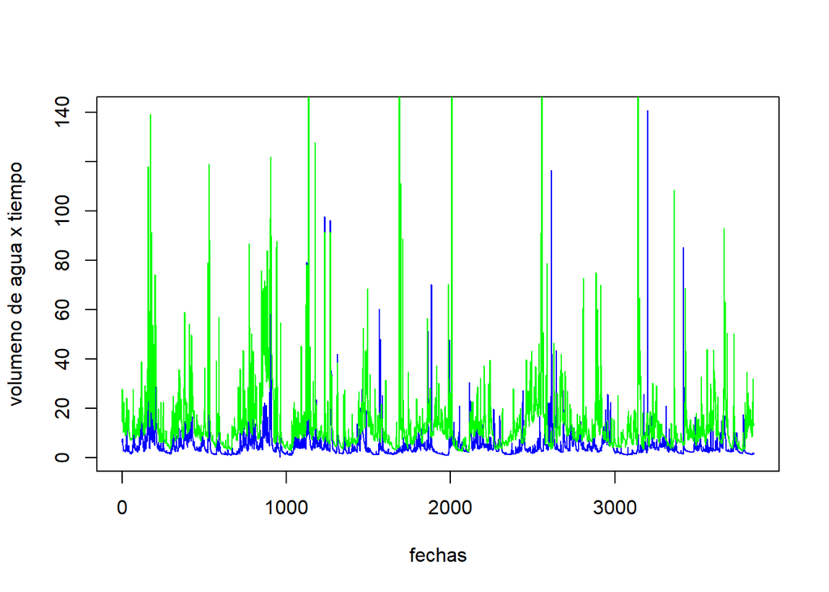

```r
plot(inp[,2], type = "l", col="blue", xlab = 'fechas', ylab = 'volumeno de agua x tiempo')
lines(inp[,3], col="green")
```

#### para conocer la estadistoca descriptiva de los datos utilizamos el comando **summary** , esto con el fin de ver como están distribuidos los datos correspondientes

```r
summary(inp[,2:3])
```

```
##  Pandora.mm..637km2. Banano.mm..90km2.
##  Min.   :  0.180     Min.   :  2.43
##  1st Qu.:  2.390     1st Qu.:  6.88
##  Median :  3.590     Median : 10.18
##  Mean   :  5.459     Mean   : 14.28
##  3rd Qu.:  5.900     3rd Qu.: 15.46
##  Max.   :140.650     Max.   :384.00
```

#### histogramas para visualizar la estadistica descriptiva de los datos

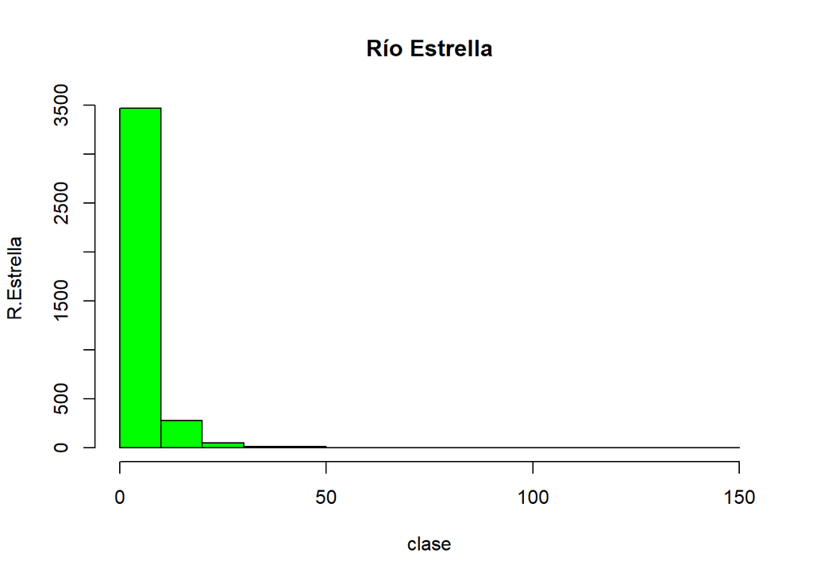

```r
hist(inp[,2], col="green",main= 'Río Estrella', xlab= 'clase', ylab = 'R.Estrella')
```

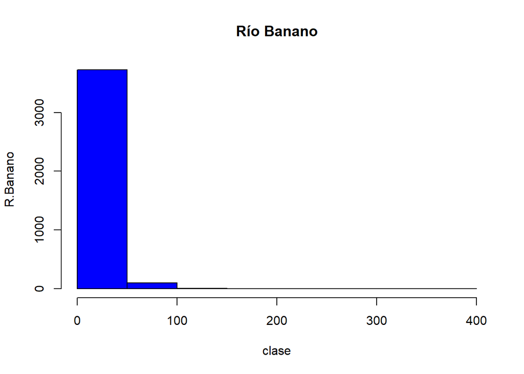

```r
hist(inp[,3], col="blue",main= 'Río Banano', xlab= 'clase', ylab = 'R.Banano')
```

#### se otorgan nombre a cada columna para facilitar la manipulación y se hace un grafico para probar el comando **attach**

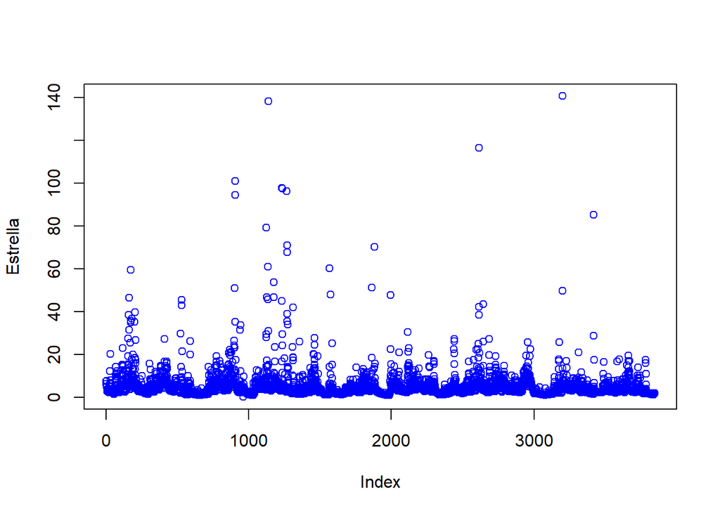

```r
names(inp) <- c("fecha", "Estrella", "Banano")
attach(inp)
plot(Estrella, col="blue")
```

#### seguidamente se difine el formanto de las fechas, con el comando **striptime** para poder hacer en analisis más especifico

```r
tempdate <- strptime(inp[,1], format= "%d/%m/%Y")
```

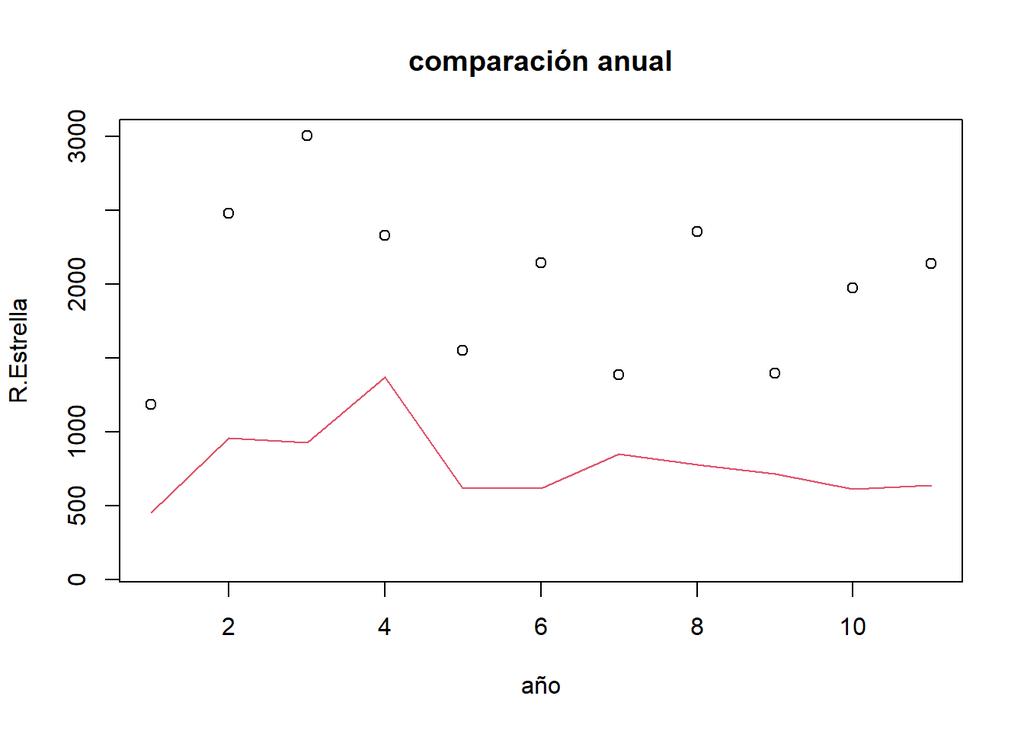

```r
MAQ_Estrella <- tapply(Estrella, format(tempdate, format= "%Y"), FUN=sum)
MAQ_Banano <- tapply(Banano, format(tempdate, format= "%Y"), FUN=sum)

write.csv(rbind(MAQ_Estrella, MAQ_Banano), file="MAQ.csv")

plot(MAQ_Banano, ylim=c(100,3000), main= 'comparación anual', xlab= 'año', ylab= 'R.Estrella' )
lines(MAQ_Estrella, col=2)
```

#### se hace lo mismo que el paso anterior pero en esta vez en lugar de años vamos a usar los meses

```r
MMQ_Estrella <- tapply(Estrella, format(tempdate, format= "%m"), FUN=sum)
MMQ_Banano <- tapply(Banano, format(tempdate, format= "%m"), FUN=sum)
```

### Analisis de correlación

#### utilizando el comando **spearman**, se realiza para saber si las cuencas tinen una relación cuantificable

```r
corinp <- cor (inp[,2:3] , method= "spearman")

inp.lm <- lm(inp[,2] ~ inp[,3], data=inp)
summary(inp.lm)
```

```
##
## Call:
## lm(formula = inp[, 2] ~ inp[, 3], data = inp)
##
## Residuals:
##     Min      1Q  Median      3Q     Max
## -71.297  -2.267  -1.155   0.774 135.889
##
## Coefficients:
##             Estimate Std. Error t value Pr(>|t|)
## (Intercept)  2.70503    0.15174   17.83   <2e-16 ***
## inp[, 3]     0.19290    0.00707   27.28   <2e-16 ***
## ---
## Signif. codes:  0 '***' 0.001 '**' 0.01 '*' 0.05 '.' 0.1 ' ' 1
##
## Residual standard error: 7.025 on 3843 degrees of freedom
## Multiple R-squared:  0.1623, Adjusted R-squared:  0.162
## F-statistic: 744.4 on 1 and 3843 DF,  p-value: < 2.2e-16
```

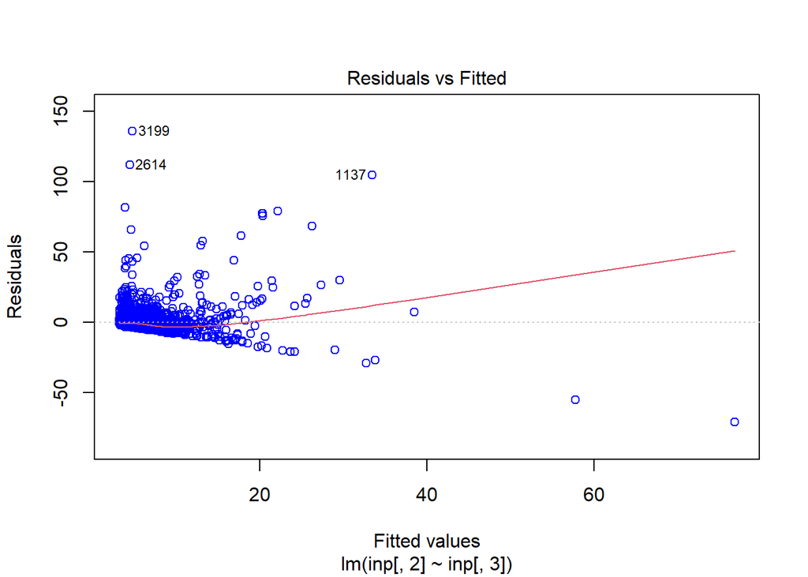

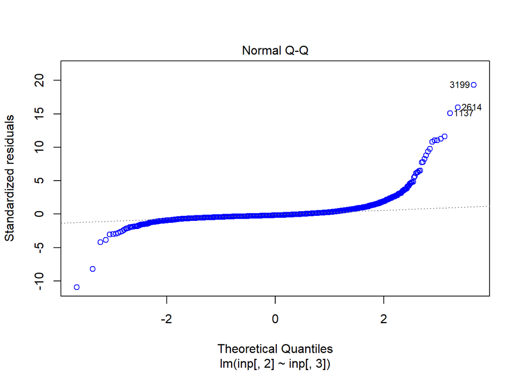

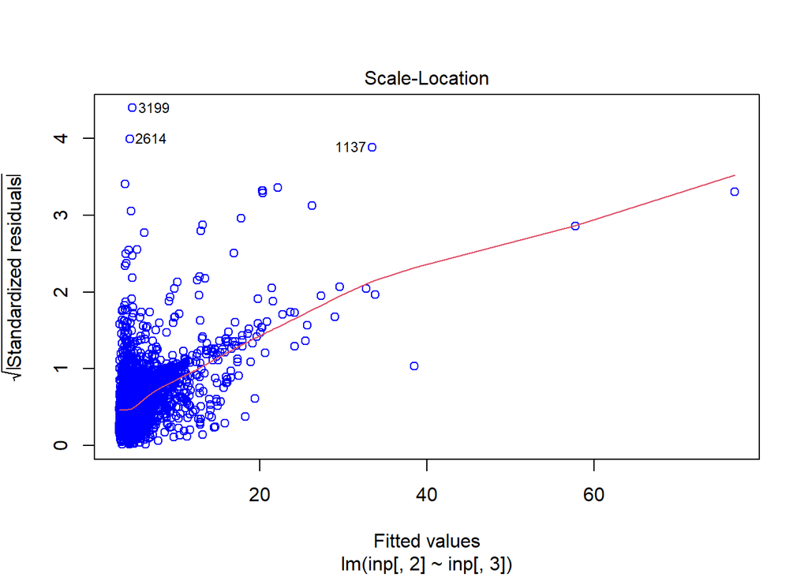

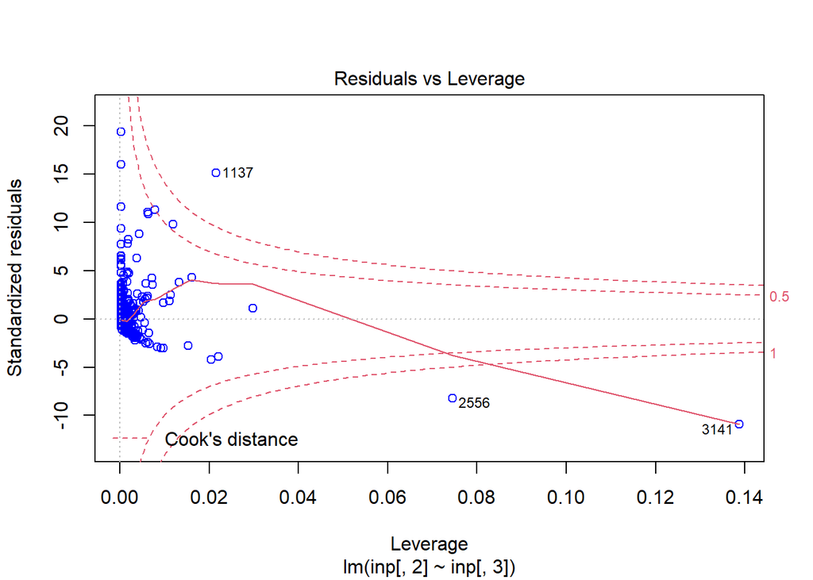

```r
plot(inp.lm, col= "blue")
```

### .